# Renting The House

Currently there are a lot of unmet expenses causing you anxiety. Jonah and I have been going back and forth. And, we think we have a solution by renting it out through Airbnb etc.

## Current

Here is my estimation of the current monthly expenses for the house:

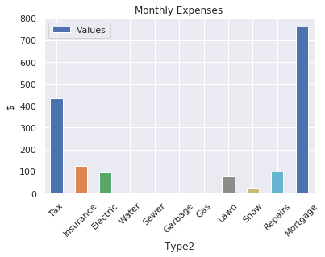

```python
import pandas as pd
import matplotlib.pyplot as plt
import seaborn as sns; sns.set()
%matplotlib inline

data = pd.read_csv('house.csv')
expenses_monthly = data[data['Type1'] == 'Expenses']
expenses_monthly.iloc[:,1:].plot(x='Type2', y='Values', kind='bar', rot=45)
plt.ylabel('$')
plt.title('Monthly Expenses')
```

Monthly:

```python
expenses_monthly.Values.sum()
```

```
1613.67
```

Yearly:

```python
expenses_monthly.Values.sum()*12
```

```
19364.04
```

This is a large amount. Do you have plans to cover it when Grandma passes?

## Airbnb

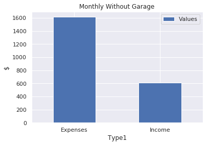

```python
data.groupby('Type1').sum().plot(kind='bar', grid=True, rot=0)
plt.title("Monthly Without Garage")
plt.ylabel('$')
```

So, there's still a 1,000 shortfall every month, but down from 1,600.

## Moving Forward

Additionally, I see a path to actually covering all the expenses and making a bit of money after renovating the garage and renting that as well.

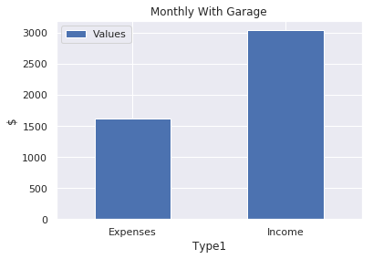

```python
data.iloc[0,2] = 80*365/12
data.groupby('Type1').sum().plot(kind='bar', grid=True, rot=0)
plt.title("Monthly With Garage")
plt.ylabel('$')
```

Assuming we can rent the garage for 80/night, continue to rent the rooms in the house for a couple years, I think we can sell it for ~600,000. I can make this money last for you for the rest of your life. You won't have anymore financial problems.

## Other Living Arrangements

But, I need you to be out of the house to make this work. I know you mentioned Pittsburgh and you're interested in going to school for music. I also have a couple other options for you based on my travels over the last two years:

- Colombia
  - incredibly cheap: 250/month for rent and food
  - most beautiful place I've seen. More so than Thailand.
- Mexico
  - cheap: 400/month for rent and food. 4/ride with Uber
  - Southern California, minus the prices
- Ypsilanti
  - cheap compared to Ann arbor: 1600/month for rent and food

## Music Teaching

I know you want to go back to school, but I think your main goal is to have an impact on others through sharing your love for piano with them. A cheaper, easier, more effective way to do that is taking online courses through Udemy/Coursera and publishing your content on Youtube.

- Udemy
  - [Teaching Music: Start teaching an instrument successfully](https://www.udemy.com/teaching-piano-a-quick-guide-for-begginers/)
  - [Music Pedagogy: 7 advices to teach a musical instrument](https://www.udemy.com/music-pedagogy/)
- Coursera
  - [Fundamentals of Music Theory from The University of Edinburgh](https://www.coursera.org/learn/edinburgh-music-theory)
  - [Developing Your Musicanship from Berklee College of Music](https://www.coursera.org/specializations/musicianship-specialization)

If you search YouTube for "learn piano" you'll see a lot of videos from different people. Some with many views, some with little. But, think about how long one of your lessons are (1 hour) and the number of students you have at any one time (one). Then think about a YouTube video you made to teach children their first piano chord. Say it gets 200 views. How long would it take you to teach 200 students in real life? 200 hours? Yet, you can make one 10 minute video and get the same result.

## Conclusion

Moving out and allowing Jonah and I to work towards renting out your place is a step forward. It will help you reduce your current expenses, alleviate anxiety about the future, and help me too.